# Wild plants of secondary lowland rain forest and grassland

Malcolm Ross

## 1. Introduction

The plants treated in this chapter grow in secondary lowland rain forest or in grasslands, i.e., in the forest which regrows on old fallow areas and on the grasslands that appear when regrowth doesn’t occur. The dominant characteristics of secondary forest plants are that they do not grow large enough to become canopy trees and they are intolerant of shade - they need sunlight (Henderson & Hancock 1988: 323). As long as secondary regrowth remains low enough in stature, they survive, but when they lose their dominance to taller trees typical of the primary rain forest canopy, they cease to reproduce at that location (see ch.2, §3.2.2).

If, as seems to be the case, there was little or no agriculture in the Bismarck Archipelago before the arrival of the ancestors of Proto Oceanic (POc) speakers (see ch.2, §4), then one might infer that there was no secondary regrowth and no grassland in the region in POc times. However, regrowth would certainly have occurred in New Britain in the wake of volcanic eruptions which must on occasion have wiped out tracts of primary forest.[^1] Because grasslands occur primarily in drier areas, there is still very little grassland in the Bismarcks.

If, then, there was relatively little secondary forest in the Bismarcks - and what there was would ultimately have returned to primary forest - where were today’s secondary forest trees located? They would have grown in locations with sufficient gaps in the canopy to let in sunlight. The more salt-tolerant grew on the coastal edge of the littoral forest, and others grew along river and stream banks. The immediate pre-Oceanic inhabitants of the Bismarcks appear to have led fairly sedentary lives and probably sometimes replanted useful trees closer to their dwellings (see discussion in ch. 2, §4). Very little is known about their lifestyle except by inference, but they presumably lived in clearings, perhaps especially on low hilltops, and these would also have provided environments for some of today’s secondary forest trees.

One thing is clear: most of the species treated in this chapter were known to POc speakers and must have been accessible to them, otherwise POc terms would not be reconstructable in the quantity that they are.

## 2. Trees and shrubs

### 2.1. *Acalypha* spp., copper leaf, B *redlif* (Euphorbiaceae)

Peekel (1984: 308-309) distinguishes three shrubs of the genus *Acalypha*, namely *Acalypha longispica*, *Acalypha grandis* and *Acalypha wilkesiana*, all in the 2–4 m range. The first two are indigenous to the Bismarcks, the last an import from Fiji. They have hairy twigs, their flowers grow in long spikes, and two of them, *Acalypha grandis* and *Acalypha wilkesiana*, have red leaves.

*Acalypha longispica* is common in secondary forest. *Acalypha grandis* is grown as an ornamental shrub in New Ireland, but the Kwarae’ae take short poles from it, using them in small buildings, to stake yams and to plant living pig fences (Kwa’ioloa & Burt 2001: 148).

POc *ka[(r,l)a]qabusi appears to have denoted a taxon including at least *Acalypha longispica* and *Acalypha grandis*. The syllable *-(r,l)a- is absent from the Proto Meso-Melanesian form, but present in PEOc. It may or may not have been present in POc. Weakly supported PEOc *(k)a(r,l)adroŋ appears also to have denoted one or more *Acalypha* species. The two PEOc etyma apparently share the initial element *ka(r,l)a-, with an ambiguous liquid: North/Central Vanuatu and Kiribati reflexes point to *-r-, SE Solomonic and Tongan to *-l-, and other Polynesian languages to either. South Vanuatu languages reflect *-n-, which I take to be an idiosyncratic local innovation.

Whistler (1991b: 51-52) glosses the Tongan reflex ‘cat’s tail’ (*pusi* ‘cat’ ), arguing that as the cat was a European introduction to Tonga, the name must be post-contact. However, this cognate set gives the lie to this interpretation.

| **POc** |  | *ka[(r,l)a]qabusi | ‘*Acalypha* spp.’ |
| --- | --- | --- | --- |
| **Proto Meso-Melanesian** |  | *kaqabusi | ‘*Acalypha* spp.’ |
| MM | Kara (East) | *kavus* | ‘*Acalypha longispica*’ (zero for †*-l-* or †*-r-*) |
| MM | Lihir | *buis* | ‘*Acalypha wilkesiana*’ |
| MM | Patpatar | *kakabus* | ‘*Acalypha longispica*’ (zero for †*-l-* or †*-r-*) |
| MM | Kia | *ɣabusi* | ‘*Acalypha grandis*’ (W. McClatchey, pers. comm.) |
| MM | Maringe | *ɣabusi* | ‘*Acalypha caturus*’ (W. McClatchey, pers. comm.) |
| **PEOc** |  | *ka(r,l)aqabusi | ‘*Acalypha* sp.’ |
| SES | Kwara’ae | *ʔalabusi* | ‘*Acalypha grandis*’ |
| NCV | Neve’ei | *no-xorabis* | ‘tree sp.’ (J. Lynch, pers. comm.) |
| NCV | Big Nambas | *n-iratᫀ* | ‘hardwood tree sp. used for digging sticks’ (J. Lynch, pers. comm.) |
| NCV | Uripiv | *n-oɾʙus* | ‘*Acalypha* sp.’ |
| **PSV** |  | *na-ɣniabʷus | ‘*Acalypha* sp.’ |
| SV | Sye | *no-ɣnompi* | ‘*Acalypha* sp.’ |
| SV | Anejom̃ | *ne-ɣñopʷoθ* | ‘*Acalypha* sp.’ |
| **PCP** |  | *ka(r,l)aqabusi | ‘*Acalypha* spp.’ |
| Fij | Wayan | *karabusi* | ‘*Acalypha repanda*’ |
| Fij | Bauan | *karabuði* | ‘*Acalypha insulana*, *Acalypha grandis*, *Acalypha wilkesiana*’ |
| Pn | Tongan | *kala-kalaʔapusi* | ‘*Acalypha* spp.’ (*-s-* for †*-h-*) |
| Pn | Anutan | *kara-karapui* | ‘*Acalypha grandis*’ |
| Pn | Tuvalu | *kala-kalāpuhi* | ‘*Acalypha grandis*’ |
| Pn | East Futunan | *kalaʔapusi* | ‘*Acalypha grandis*’ |
| Pn | East Uvean | *kalāpuhi* | ‘*Acalypha grandis*’ |
| Pn | Tikopia | *karāpusi* | ‘*Acalypha hispida* and *Macaranga* spp.’ |

| **PEOc** |  | *(k)a(r,l)adroŋa | ‘*Acalypha* sp.’ |
| --- | --- | --- | --- |
| SES | Ulawa | *aladoŋa* | ‘*Acalypha* sp.’ (W. McClatchey, pers. comm.) |
| Mic | Kiribatese | *aroŋa* | ‘*Acalypha amentacea*’ |

### 2.2. *Alphitonia* spp. (Rhamnaceae)

Trees of the genus *Alphitonia* are sub-canopy trees which are conspicuous because of their light grey bark and leaves which are shiny brown or green on the upper surface but grey, white or silver underneath with brown veins (Peekel 1984: 345). The Bismarcks species named by Peekel are *Alphitonia macrocarpa*, 8-10 m tall, and *Alphitonia excelsa*, 10–20 m tall. Apparently very similar to the latter are *Alphitonia incana* (syn. *A. philippensis*) and *Alphitonia zizyphoides* (whitewood, B *waetwud*, huremi), the latter growing up to 30 m tall. Found respectively in NW Island Melanesia and from Vanuatu to eastern Polynesia, they are important in house construction and in traditional medicine. The leaves were used as soap (Powell 1976, Whistler 1991b: 126, Wheatley 1992: 193-195, Kwa’ioloa & Burt 2001: 116, Thomson & Thaman 2006).

If Lukep (Pono) (NNG) *doi* ‘*Cerbera manghas*’ is cognate (the two trees are of similar size and have similarly shaped leaves), then POc *doi is reconstructable, but only with the vague sense ‘a medium-sized tree sp.’.

| **PCP** |  | *doi | ‘*Alphitonia* spp.’ |
| --- | --- | --- | --- |
| Fij | Wayan | *doi* | ‘*Alphitonia zizyphoides* and *Alphitonia franguloides*’ |
| Fij | Bauan | *doi* | ‘*Alphitonia excelsa*’ |
| Pn | Tongan | *toi* | ‘*Alphitonia zizyphoides*’ |
| Pn | Niuean | *toi* | ‘*Alphitonia zizyphoides*’ |
| Pn | East Futunan | *toi* | ‘tree sp.’ |
| Pn | East Uvean | *toi* | ‘*Alphitonia excelsa*’ |
| Pn | Samoan | *toi* | ‘*Alphitonia zizyphoides*’ |
| Pn | Rarotongan | *toi* | ‘*Alphitonia zizyphoides*’ |
| Pn | Tahitian | *toi* | ‘*Alphitonia zizyphoides*’ |

cf. also:

| NCV | Raga | *dovae* | ‘*Alphitonia zizyphoides*’(Walsh 2004) |
| --- | --- | --- | --- |

### 2.3. *Commersonia bartramia* (Sterculiaceae)

*Commersonia bartramia* is a common small bushy tree which grows up to 15m in height, and is particularly common in secondary forest. It has a thin trunk, often crooked or leaning when it is competing with other trees for light (Wheatley 1992: 221).

*Commersonia bartramia* grows fast and, if the light allows it, straight, and is thus a valued timber in the Bismarcks and the Solomons, as it provides numerous rafters. The wood is lightweight, tough, cardboard-like and termite-proof. However, the Kwara’ae regard it as good only for building cookhouses. On New Britain and in the Solomons it is regarded as good firewood. In both the Bismarcks and the Solomons the bast (inner bark fibre) is an important source of cordage, used to make fishing lines, nets and baskets, and among the Nakanai the bast is beaten into masks (Floyd 1954, Powell 1976, Peekel 1984: 371, Henderson & Hancock 1988: 194, Kwa’ioloa & Burt 2001: 160).

The POc term for *Commersonia bartramia* was *jamaR. The Mwotlap, Mota and Vera’a reflexes include a reflex of the prefix *mala- ‘like’. One would thus expect them to denote a plant that resembled *Commersonia bartramia*, but they apparently denote *Commersonia bartramia* itself (ch.2, §7.1.4).

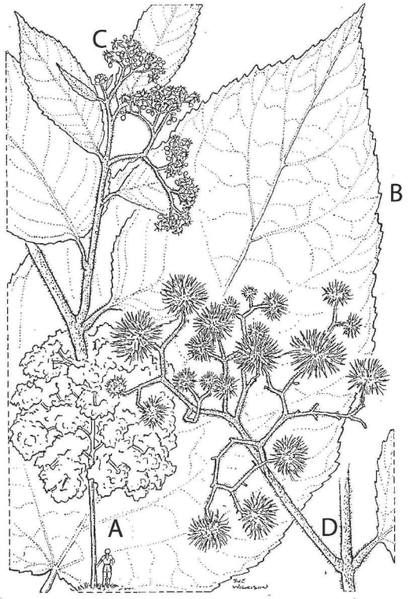

**Figure 8.1:** *Commersonia bartramia*: **A**, tree; **B**, leaf: **C**, stem bearing leaves and flowering shoot; **D**, ageing mature fruit.

| **POc** |  | *jamaR | ‘*Commersonia bartramia*’ |
| --- | --- | --- | --- |
| MM | Marovo | *jamara* | ‘*Commersonia bartramia*’ (Henderson and Hancock 1988: 194) |
| TM | Natügu | *tame-tame* | ‘*Commersonia bartramia*’ (Henderson and Hancock 1988: 194) |
| SES | West Guadalcanal | *jemara* | ‘*Commersonia bartramia*’ (borrowed from a NW Solomonic language) |
| SES | Kwara’ae | *da-dame* | ‘*Commersonia bartramia*’ (Henderson and Hancock 1988: 194) |
| SES | Kwaio | *da-dame* | ‘*Commersonia bartramia*’ |
| SES | Lau | *da-dame* | ‘*Commersonia bartramia*’ |
| NCV | Mwotlap | *na-(may)ham* | ‘*Commersonia bartramia*’ |
| NCV | Mota | *(mara)sama* | ‘*Commersonia bartramia*’ |
| NCV | Vera’a | *(mar)sama* | ‘*Commersonia bartramia*’ |
| SV | Sye | *ne-hemar* | ‘*Commersonia bartramia*’ |
| Fij | Bauan | *sama* | ‘*Commersonia bartramia*’ (Keppel et al. 2005) |

### 2.4. *Glochidion philippicum*, little cheese tree, B *namalao* (Euphorbiaceae)

The little cheese tree, *Glochidion philippicum* (syn. *G. ramiflorum*), grows 10–20 m tall, and is common in secondary forest. Its fruit are dry greyish green disc-like capsules shaped like a Dutch cheese round or a flattened Australian pumpkin, which split open to reveal red or orange seeds (Peekel 1984: 295).

The dark brown wood is strong and durable and provides houseposts and other house members at least in Kwara’ae and in parts of Vanuatu (Wheatley 1992: 93-95, Kwa’ioloa & Burt 2001: 112). The Kwara’ae also plant it to form living fences. Among the Nakanai the red seeds provide a dye and the sap provides caulking material and is mixed with clay to make a paint for decorating canoes (Floyd 1954). The bark has medicinal uses (Record 1945).

| **POc** |  | *mʷala(q)u | ‘*Glochidion philippicum*’ (Paul Geraghty: *m(e,o)la(q)u, see Lynch 2001c: 240) |
| --- | --- | --- | --- |
| PT | Muyuw | *(ya)manau* | ‘*Garcinia* sp.’ (Damon 1995) |
| MM | Madak | *(vap)mala* | ‘*Glochidion philippicum*, *Glochidion gimi*’ |
| MM | Patpatar | *malau* | ‘*Glochidion philippicum*’ |
| MM | Tolai | *malau* | ‘*Glochidion philippicum*’ |
| MM | Teop | *muaeru* | ‘*Glochidion* sp.’ |
| **PROc** |  | *mʷala(q)u | ‘*Glochidion* spp.’ |
| NCV | Mwotlap | *maluw* | ‘*Glochidion* spp.’ |
| NCV | Mota | *malao* | ‘tree sp.’ |
| NCV | Apma | *ma-mlah* | ‘*Glochidion* spp.’ |
| NCV | Raga | *mʷa-mʷalau* | ‘*Glochidion stipulare* (?)’ (Walsh 2004) |
| NCV | Paamese | *maiao* | ‘*Glochidion* spp.’ |
| **PSV** |  | *na-mel(p)au | ‘*Glochidion* spp.’ (Lynch 2001c) |
| SV | Sye | *na-melpau* | ‘*Glochidion philippicum*’ (*-p-* is unexplained) |
| SV | Anejom̃ | *na-mlau* | ‘*Glochidion perakense*’ |
| Fij | Bauan | *molau* | ‘*Glochidion* sp.’ |

PWOc *jimʷaR or *jimiR in all probability denoted the caulking substance made from *Glochidion* sap rather than the tree itself, but in some languages the word has been applied to the tree. The distribution of reflexes of the alternants *jimʷaR (NNG, PT) and *jimiR (NNG, MM) makes it difficult to know which was the earlier form. However, the Meso-Melanesian reflexes are from languages close to the boundary between Meso-Melanesian and North New Guinea, raising the possibility that the MM forms are borrowings from NNG. This would leave *jimʷaR as the more probable PWOc form.

| **PWOc** |  | *jimʷaR, *jimiR | ‘sap used for caulking’ (Ross 1988: 79) [^2] |
| --- | --- | --- | --- |
| NNG | Malai | *dimir* | ‘caulking material’ |
| NNG | Gitua | *simer* | ‘caulking material’ |
| NNG | Malalamai | *simaɬ* | ‘putty nut, *Parinarium laurinum*’ (Lincoln 1976) |
| NNG | Tami | *jim* | ‘caulking material’ |
| NNG | Mangap | *zim* | ‘tree sp.; sap of this tree sp., used as glue and as caulking’ |
| NNG | Lukep | *dim* | ‘caulking material’ |
| NNG | Numbami | *dimila* | ‘sap, putty; caulking material’ |
| NNG | Gedaged | *dim* | ‘tree, bark used as putty’ |
| NNG | Takia | *dim* | ‘tree sp., resin used as putty and as glue to mix with paints’ |
| NNG | Wab | *lim* | ‘caulking material’ |
| NNG | Mindiri | *dim* | ‘caulking material’ |
| NNG | Dami | *dimi* | ‘caulking material’ |
| PT | Muyuw | *(a)simʷal(gayas)* | ‘*Glochidion* sp.’ (Damon 2004) |
| MM | Bola | *dimi* | ‘*Glochidion* sp.; the sap is mixed with red clay to make canoe paint’ |
| MM | Nakanai | *gimi* | ‘*Glochidion* sp.’ |

### 2.5. *Macaranga* spp., P *sa’osa’o*, B *navenue* (Euphorbiaceae)

There are a number of species of *Macaranga* growing in the Bismarcks and the Solomons and appearing as the glosses of items in the cognate sets below, but they are all rather similar. All are shrubs or small trees, usually 5-10 m and occasionally 15 m tall. Their saplings need light and do not flourish in primary forest, so they are found where the habitat is more open and often in garden regrowth or secondary forest (Powell 1976, Peekel 1984:305-207, Henderson & Hancock 1988: 196-197, Wheatley 1992:99-101, Kwa’ioloa & Burt 2001: 147, Hviding 2005: 109, 148).

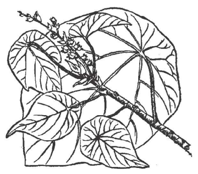

**Figure 8.2:** *Macaranga* tanarius.

From the Bismarcks to Vanuatu much the same uses are reported for *Macaranga* species. The lightweight wood is used for rafters, wall frames and roof battens where better timber is not available, and for cages for pet birds. The wood is fast-burning and good for roasting food. The leaves are used to clean children’s noses and for personal hygiene. Additionally the Bola of New Britain use the wood for outrigger booms, the leaves for wrapping, and the fruit for medicinal purposes (Lentfer 2003, Powell 1976).

The only species singled out for more detailed description in the sources is *Macaranga tanarius*, which occurs with green or red leaves, up to 30cm in diameter, the veins of which radiate out from a point just off the centre where the petiole is attached. Its tiny cream flowers form large clusters. A bundle of leaves worn around the neck serves as perfume, and the leaves are among those rubbed on the body before ceremonial dancing (Record 1945, Peekel 1984: 307, Wheatley 1992: 101).

Four reconstructions are offered, two for POc, two for PWOc, and all with the meaning ‘*Macaranga* spp.’. They are POc *koka, POc *pinu(q)an, PWOc *bara and PWOc *kobo. Of these the only one for which a more specific denotatum can be inferred is POc *pinu(q)an, glossed as ‘taxon of *Macaranga* spp., perhaps *Macaranga involucrata*’ .

POc *koka probably denoted several *Macaranga* species. Known reflexes with this meaning are found in New Ireland (MM) and in the Banks Islands of extreme north Vanuatu (NCV). The distribution of the items in the set below suggests that the term was reapplied to *Bischofia javanica* (ch.7, §5 .1) in Eastern Oceanic. The grounds for the reapplication are unclear, as *Macaranga* species are 5-10 m tall, whereas *Bischofia javanica* is a canopy tree up to 30m.

| **POc** |  | *koka | ‘*Macaranga* spp.’ |
| --- | --- | --- | --- |
| MM | Patpatar | *koka* | ‘*Macaranga quadriglandulosa*’ |
| MM | Tolai | *koko* | ‘*Macaranga quadriglandulosa*’ |
| SES | Kwara’ae | *ʔoʔa* | ‘*Glochidion angulatum*’ |
| NCV | Hiw | *nə-ɣɒɣə* | ‘*Macaranga tanarius*’ |
| NCV | Mwotlap | *no-ɣoɣ* | ‘*Macaranga tanarius*’ |
| **PEOc** |  | *koka | ‘tree sp., *Bischofia javanica*’ (POLLEX) |
| **PCP** |  | *koka | ‘tree sp., *Bischofia javanica*’ (see ch.7, §5.1) |

PMP *binu(q)an below is reconstructed on the basis of the Oceanic data and of Tagalog *binuaŋ* ‘*Macaranga tanarius*, *Macaranga grandifolia*’ (Madulid 2001b: 191).

| **PMP** |  | *binu(q)an | ‘*Macaranga* spp., perhaps *Macaranga involucrata*’ |
| --- | --- | --- | --- |
| **POc** |  | *pinu(q)an | ‘*Macaranga* spp., perhaps *Macaranga involucrata*’ |
| MM | Solos | *hunuan* | ‘*Macaranga* spp.’ |
| SES | Gela | *vinua* | ‘*Macaranga tanarius*’ (W. McClatchey, pers. comm.) |
| SES | Ghari | *venua* | ‘*Macaranga involucrata*’ |
| SES | Kwara’ae | *fino-fino* | ‘*Macaranga aleuritoides*’ |
| SES | Kwara’ae | *(taŋa)fino* | ‘*Macaranga aleuritoides*’ |
| SES | Kahua | *hinua (goro)* | ‘*Macaranga involucrata*’ (Henderson and Hancock 1988) |
| NCV | Mota | *vin-vin* | ‘a tree’ |
| NCV | Ambae | *vinue* | ‘*Macaranga involucrata*’ |
| NCV | Nduindui | *venue* | ‘*Macaranga involucrata*’ (Wheatley 1992: 99) |
| NCV | Nduindui | *venue (boe)* | ‘*Macaranga tanarius*’ (Wheatley 1992: 101) |
| NCV | Uripiv | *ne-vnu* | ‘*Macaranga* sp.’ |
| NCV | Naman | *ni-vnu* | ‘*Macaranga* sp.’ |
| NCV | Neve’ei | *ni-vinu* | ‘*Macaranga* sp.’ |
| NCV | Larëvat | *nə-vənu* | ‘*Macaranga* sp.’ |
| NCV | Nese | *ne-vᫀine* | ‘*Macaranga* sp.’ |
| NCV | Paamese | *hinu (ahen)* | ‘*Macaranga involucrata*’ (Wheatley 1992: 99) |
| NCV | Paamese | *hinu (wa)* | ‘*Macaranga tanarius*’ (Wheatley 1992: 101) |
| NCV | Lewo | *(puru)venua* | ‘a tree’ |

| **PWOc** |  | *bara | ‘*Macaranga* spp.’ |
| --- | --- | --- | --- |
| NNG | Poeng | *vala-vala* | ‘*Macaranga* spp.’ |
| PT | Misima | *(e)bal* | ‘*Macaranga tanarius*’ |
| MM | Tolai | *bara-bara* | ‘*Macaranga* sp.’ (Record 1945) |
| MM | Patpatar | *(pala)bara* | ‘*Macaranga aleuritoides*’ |
| MM | Petats | *vana-van* | ‘*Macaranga aleuritoides*’ (Record 1945) |
| MM | Teop | *bana-bana* | ‘*Macaranga aleuritoides*’ (Record 1945) |

There are formal questions associated with the reconstruction of PWOc *kobo ‘taxon of *Macaranga* spp.’. First, Far-east Manggarai, Razong, Rembong (all CMP) *kebak* ‘*Macaranga tanarius*’ (Verheijen 1990: 226) is probably cognate with the items below. If so, we would expect a POc form †*koba(k) rather than *kobo, so final PWOc *-o may represent an idiosyncratic innovation. Second, *kobo seems to have been conflated with *kope ‘bamboo sp.’ (see ch. 13, §3.1) in Motu.

| **PWOc** |  | *kobo | ‘taxon of *Macaranga* spp.’ |
| --- | --- | --- | --- |
| PT | Muyuw | *(a)kobʷow* | ‘*Macaranga tanarius*’ |
| PT | Motu | *kohe* | ‘*Macaranga tanarius*’ (for †_kobo) |
| MM | Bola | *ko-kobo* | ‘*Macaranga aleuritoides*’ |
| MM | Nakanai | *ko-kobo* | ‘*Macaranga tanarius*’ |
| MM | Nakanai | *ko-kobo(-kiuka)* | ‘*Macaranga aleuritoides*, with deeply serrated leaves’ |
| MM | Kara (East) | *(və)kof* | ‘*Macaranga quadriglandulosa*’ |
| MM | Kara (East) | *(və)kof(se)* | ‘*Macaranga urophylla*’ |

### 2.6. *Pipturus argenteus* (syn. *Pipturus velutinus*, *Pipturus incanus*, *Urtica argentea*, *Urtica incana*) (Urticaceae)

*Pipturus argenteus* is a small tree, 3-6 m tall, growing mainly in secondary forest. It has a short bole and leaves which are dark green on the upper surface and greyish green to silver underneath. The small white fruits are edible and sweet, but are not harvested systematically: they are eaten by children or as a bush snack. The bast is a useful cordage material, but the timber is used if at all for temporary shelters. It is unsuitable for house-building and is poor firewood, because it refuses to burn and because the smoke is an irritant (Peekel 1984: 153, Whistler 1991b: 99, Wheatley 1992, Kwa’ioloa & Burt 2001: 157, Thieberger 2006b). In Papua New Guinea the leaves are sometimes eaten, but it is not clear whether this includes locations in the Bismarcks (French 1986:90, May 1984: 63). Arentz et al. (1989: 91) report that in part of New Britain an infusion of the leaves is used against a cough.

The POc term for *Pipturus argenteus* was *qaramʷaqi. Both instances of *q require comment here.

Blust (ACD) reconstructs PMP *adamay without initial *q-, but adds that if Sundanese *haramay* ‘Boehmeria nivea’ (a member of the family Urticacea) is cognate, then the reconstruction will be *qadamay. The Kara, Patpatar, Notsi, Pije, Nelemwa and Tongan reflexes also reflect *q-, and it is thus reasonable to infer that the PMP form was *qadamay.

There is disagreement among cognates with regard to the final *-aqi of POc *qaramʷaqi. Blust reconstructs the final *-ay of PMP *adamay with no *-q- on the basis of Cebuano *handalamay* ‘*Pipturus argenteus*’, Maranao *aramai* ‘*Pipturus* arborescens’ and the Sundanese reflex above, and so putative POc *-q- must be a post-PMP innovation. PMP *-ay is normally reflected as POc *-e, but Raga, Sye and Anejom *-ai* reflect POc *-aqi, not *-e. POc *-q- is also reflected in Kara *kaimek* and Patpatar *karanek*, which sporadically retain it as *k*. POc *-aqi is also arguably the source of *-e* in Marshallese *armʷe* and of long *-ē* in Wayan *rōmē*. Against the reconstruction of *-aqi are the Seimat, Apma, S Efate and all Central Pacific reflexes other than Wayan. Geraghty (1990: 55) accounts for long final *-ā* in Central Pacific reflexes by reconstructing PEOc/PCP *(q)aromʷaRa. PEOc *-R- is usually lost in PCP but occasionally retained as *-l-, which, Geraghty (1990: 91) suggests, is reflected in NE Viti Levu *ŋala* ‘*Pipturus* sp.’. However, short of not just one but two syllables, this is a questionable reflex, and so I reconstruct PCP *qaromʷ(ē,ā). The ambiguity of the final long vowel is due to the disagreement between Wayan *-ē* and Lau Fijian and Polynesian *-ā*. Geraghty is right, however, to take the long final vowel seriously, and it is not clear to me how this innovation arose.

| **PMP** |  | *qadamay | ‘*Pipturus argenteus*’ (ACD) |
| --- | --- | --- | --- |
| **POc** |  | *qaramʷaqi | ‘*Pipturus argenteus*’ (Geraghty 1990: PEOc *(q)aromʷaRa) |
| Adm | Seimat | *ahoma* | ‘a small tree, from the bark of which fishing lines and nets are made’ (Sorensen 1950) |
| MM | Kara (East) | *kaimek* | ‘*Pipturus argenteus*’ |
| MM | Notsi | *karamet* | ‘*Pipturus argenteus*’ (*-t* unexplained) (Holdsworth et al. 1978) |
| MM | Patpatar | *karanek* | ‘*Pipturus argenteus*’[^3] |
| NCV | Vera’a | *demie* | ‘*Pipturus argenteus*’ |
| NCV | Raga | *adomai* | ‘*Pipturus argenteus*’ |
| NCV | Apma | *odomʷa* | ‘*Pipturus argenteus*’ |
| NCV | South Efate | *na-ⁿrmʷa* | ‘*Pipturus argenteus*’ |
| SV | Sye | *na-nmai* | ‘*Pipturus argenteus*’ |
| SV | Anejom̃ | *ne-lmʷai* | ‘*Pipturus argenteus*’ |
| NCal | Pije | *hahmʷe* | ‘*Pipturus argenteus*’ |
| NCal | Nêlêmwâ | *hâlamʷi* | ‘*Pipturus argenteus*’ |
| NCal | Iaai | *arma* | ‘*Pipturus argenteus*’ |
| Mic | Kiribatese | *aroma* | ‘*Pipturus argenteus*’ |
| Mic | Marshallese | *armʷe* | ‘*Pipturus argenteus*’ |

| **PCP** |  | *qaromʷ(ē,ā) | ‘shrub or tree sp., *Pipturus* sp.; bark used for cordage’ |
| --- | --- | --- | --- |
| Fij | Wayan | *rōmē* | ‘generic for three spp. of Urticaceae: *Boehmeria virgata*, *Leucosyke corymbulosa* and *Pipturus argenteus*’ |
| Fij | Lau (Eastern Fijian) | *roŋā* | ‘*Pipturus* sp.’ (Geraghty 1990: 91) |
| **PPn** |  | *q[a,o]loŋā | ‘shrub or tree sp., *Pipturus* sp.; bark used for cordage’[^4] |
| Pn | Tongan | *ʔoloŋā* | ‘*Pipturus argenteus*’ |
| Pn | Nukuria | *oloŋā* | ‘*Pipturus* sp.’ |
| Pn | Takuu | *arona* | ‘plant sp’ |
| Pn | Luangiua | *loloŋa* | ‘tree sp., fishing-line from bark.’ |
| Pn | Ifira-Mele | *roŋā* | ‘*Pipturus* sp.’ |
| Pn | Rarotongan | *ʔoroŋā* | ‘*Pipturus argenteus*’ |
| Pn | Tahitian | *rooʔā* | ‘*Pipturus* sp.’ |
| Pn | Tuamotuan | *roŋā* | ‘*Pipturus incanus* var. tuamotensis’ |
| Pn | Marquesan | *hoka* | ‘shrubs or small trees, *Pipturus* spp.’ |

### 2.7. *Rhus taitensis* (syn. *Rhus retusa*, *Rhus rufa*), P *akwasi* (Anacardiaceae)

*Rhus taitensis* is a tree which grows to 10–15 min secondary forest. At flowering time it is covered in white flowers. This is a deciduous tree, and when the leaves are ready to fall, they turn bright red (Peekel 1984: 325).

In New Ireland fishing net floats are made from the white wood. When it is cut down and has dried out, it splits exceptionally easily, but has few uses. In Kwara’ae the tree is a source of protein food in the form of the grubs of a caterpillar that feeds on it (Kwa’ioloa & Burt 2001: 108). On New Hanover (immediately to the north of New Ireland) the young shoots are eaten by women to induce abortion and used for a variety of medicinal purposes (Holdsworth et al. 1982)

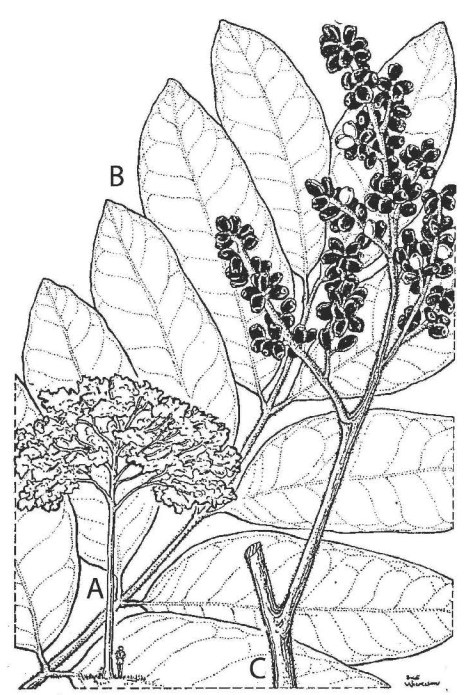

**Figure 8.3:** *Rhus taitensis*: **A**, tree; **B**, stem bearing leaves; **C**, branch bearing fruit.

The premier uses of *Rhus taitensis*, however, all have to do with producing black colouring materials. In Marovo pandanus leaves are stained black by boiling them in a mixture that includes pounded *Rhus taitensis* leaves and a particular seaweed. Gardner & Pawley (2006) report a similar process from Waya Island, where the dye was also used to blacken hair. The charcoal of *Rhus taitensis* was an ingredient in the black putty used for the caulking and glossy surface finish of war canoes in Marovo Lagoon (Hviding 2005: 131). In parts of the Solomons the pounded charcoal is mixed with *Macaranga* urophylla to make paint. In Tonga it was used in hair dye (Whistler 1991b: 121).

A number of groups in Indonesia and Melanesia practised ritual tooth-blackening as part of initiation, and this was perhaps also a custom among Proto Oceanic speakers (Chowning 1991: 48-49).[^5] Across southern New Britain the blackening material was mineral (probably manganese). In Malaita it was made from *Rhus taitensis*, and made the teeth shiny black and allegedly strong. The veins and stems were removed from the leaves, and what remained was roasted in bamboo, then pulverised. This powder was mixed with a crushed blue-black powdery rock known as *oko*, and a chemical reaction produced a black mixture which was cooked further to produce a viscous dye which was coated onto the subject’s teeth and left there for a week (during which the subject ate no solid foods). Occasionally the black would wear off after a few weeks, but usually it remained for life (Henderson & Hancock 1988: 238, Kwa’ioloa & Burt 2001: 108; see also vol.1, ch.4, §5.3).

| **POc** |  | *tawasi | ‘*Rhus taitensis*’ |
| --- | --- | --- | --- |
| MM | Lavongai | *tuas* | ‘*Rhus taitensis*’ |
| MM | Kara (East) | *(mə)rawəs* | ‘*Rhus taitensis*’ |
| SES | Kwara’ae | *akʷasi* | ‘*Rhus taitensis*’ |
| SES | Kwaio | *akʷasi* | ‘*Rhus taitensis*’ (Henderson and Hancock 1988) |
| SES | Lau | *ʔakʷasi* | ‘*Rhus taitensis*’ |
| SES | Santa Ana | *awasi* | ‘*Rhus taitensis*’ |
| Fij | Wayan | *tawa(rau)* | ‘*Rhus taitensis*’ (obsolete term; Gardner & Pawley 2006) |
| **PPn** |  | *tawahi | ‘*Rhus taitensis*’ (POLLEX) |
| Pn | Tongan | *tavahi* | ‘*Rhus taitensis*’ |
| Pn | Niuean | *tavahi* | ‘*Rhus taitensis*’ |
| Pn | Rennellese | *tabai* | ‘*Rhus taitensis*’ |
| Pn | Samoan | *tavai* | ‘*Rhus taitensis*’ |
| Pn | Tahitian | *avai* | ‘a large: timber tree’ |
| Pn | Māori | *tawai* | ‘large trees, *Nothofagus* (southern beech) spp.).’ |

### 2.8. *Trema orientalis* (syn. *Trema scaberrima*. *Trema aspera*) (Ulmaceae)

*Trema orientalis* is a secondary forest tree growing as tall as 12 m, with shiny bright green twigs and egg-shaped leaves, rough and dark green on the upper surface, pale green underneath (Peekel 1984: 131).

On the north coast of New Britain the bast serves as material for canoe lashings and for making nets to catch birds and pigs and the bark is used to wrap pork and vegetables for cooking. The wood is used for beams and as firewood (Powell 1976). Wheatley (1992: 237) reports similar uses from Vanuatu.

Blust (ACD) reconstructs PWMP *deRuŋ on the basis of western Malaya-Polynesian reflexes alone. The reflexes below show that POc *droRu(ŋ) ‘*Trema* sp.’ is reconstructable and thus that Blust’s reconstruction should be re-labelled as PMP.

| **PMP** |  | *deRuŋ | ‘*Trema orientalis*’ (Verheijen 1984; ACD: PWMP) |
| --- | --- | --- | --- |
| **POc** |  | *droRu(ŋ) | ‘*Trema orientalis*’ |
| MM | Roviana | *do-doru* | ‘tree, possibly *Trema* sp. (bark taken off in sheets)’ |
| NCV | Vera’a | *do-ndo* | ‘*Trema orientalis*’ (Wheatley 1992: 237) |
| NCV | Raga | *dou-dou* | ‘*Trema* sp.’ (Walsh 2004) |
| SV | Sye | *ne-nroŋ* | ‘*Trema cannabina*’ (J. Lynch, pers. comm.) |
| Fij | Wayan | *drou* | ‘*Parasponia andersonii*’ |
| Fij | Bua | *[drou-]drou* | ‘*Trema amboinensis*’[^6] |

### 2.9. *Trichospermum* spp. (syn. Althoffia, Grewia) (Tiliaceae)

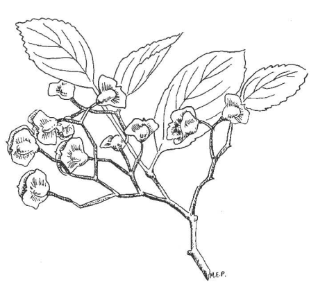

**Figure 8.4:** *Trichospermum richii*.

Peekel records two species of *Trichospermum* in New Ireland, *Trichospermum peekelii* (syn. T. fauroensis, *Trichospermum psilocladum*) in the north and *Trichospermum pleiostigma* (syn. *T. quadrivale*, Althoffia tetrapyxis) in the south, with an overlap in the Madak-speaking area.

Both species grow to 10–20 m and have a single stem with radial branches which form a roundish to conical crown. When it is in bloom, the crown is covered in fllowers and is a white mass with a sweet smell which reaches quite a distance. Because the saplings are shade-intolerant, they tend to occur in secondary regrowth, although individual specimens may attain canopy height and survive-but they are unable to reproduce.

The two species provide straight poles for rafters. They are also good firewood and are among the species that were used as fireploughs. The bark can be pulled off in strips and is used for carrying bundles of garden produce or wood, and to cover house entrances and as roofing for temporary shelters. The Kwara’ae used it to make warriors’ shields (Peekel 1984:357, Wheatley 1992:233, Kwa’ioloa & Burt 2001: 136–137).

POc *maRako ‘*Trichospermum peekelii*’ is an unproblematic reconstruction.

| **POc** |  | *maRako | ‘*Trichospermum peekelii*’ (Geraghty 1990: PEOc) |
| --- | --- | --- | --- |
| MM | Lavongai | *maŋau* | ‘*Trichospermum pleiostigmum*’[^7] |
| MM | Kara (East) | *maiau* | ‘*Trichospermum peekelii*’ |
| MM | Madak | *(vap)ma* | ‘*Trichospermum peekelii*’ |
| SES | Gela | *malaɣo* | ‘sp. of forest tree’ |
| SES | Kwara’ae | *malaʔo* | ‘*Trichospermum peekelii*’ |
| SES | ’Are’are | *marako* | ‘tree sp., a twig of which is used to indicate a taboo’ |
| SV | Anejom̃ | *n-maɣ* | ‘*Trichospermum inmac*’ (Wheatley 1992: 233) |
| **PCP** |  | *mako | ‘*Trichospermum richii*’ (for expected †*māko) |
| Fij | Wayan | *mako* | ‘tree, probably *Trichospermum richii*’ |
| Fij | Bauan | *mako* | ‘*Trichospermum richii*’ |
| Pn | Samoan | *maʔo* | ‘*Trichospermum richii*, *Melochia odorata* etc.’ |
| Pn | Tikopia | *mako* | ‘tree sp. of the woodland; wood occasionally used for outriggers’ |
| Pn | West Futunan | *mako* | ‘tree with yellow blossom’ |
| Pn | Tahitian | *mao* | ‘tree name, bark used as dye’ |
| Pn | Hawaiian | *maʔo* | ‘*Gossypium tomentosum*, *Abutilon incanum*’ |
| Pn | Māori | *mako-mako* | ‘wineberry, *Aristotelia serrata*’ |

## 3. Grasses

Although grasslands are rare in the Bismarck Archipelago, grasses of course grow there, especially on the edges of forests, around garden clearings and in secondary forest. The most common grass in the Bismarcks is *Paspalum conjugatum* (Figure 8.5, left), which can grow to a metre high (Peekel 1984: 48), but it appears to have been introduced from the New World (R. Gardner, pers. comm.). Evans (ch.3, §4.5) reconstructs POc *pali[s,j]i ‘generic term for grasses and other grass-like plants’. She notes that the generic term for a taxon quite often represents an extension of the meaning of a term for a particular and salient subtaxon. There is flimsy evidence that the PROc reflex of *pali[s,j]i was not only the generic but by this time denoted the creeping beach grass, *Thuarea involuta*, known in Hawai’i as kuroiwa grass. This is its specific denotation in both Mwotlap (NCV) and Woleaian (Mic).

Two less widely reflected terms, the reflexes of which are generic terms for grass, are POc *rabum and *(quta)quta.

| **POc** |  | *rabum | ‘grass’ |
| --- | --- | --- | --- |
| NNG | Mapos Buang | *dbu* | ‘grass in general; grass used for thatching a house’ |
| PT | Magori | *rabu(na)* | ‘grass’ |
| MM | Vitu | *rabu-rabu* | ‘grass’ |
| TM | Nagu | *lepmʉ* | ‘grass’ |
| TM | Nebao | *abəmə* | ‘grass’ |
| TM | Asumboa | *lɔbumɔ* | ‘grass’ |
| TM | Tanibili | *ubomɔ* | ‘grass’ |
| TM | Buma | *abɔ* | ‘grass’ |
| TM | Vano | *abume* | ‘grass’ |
| TM | Tanema | *abome* | ‘grass’ |

| **POc** |  | *(quta)quta | ‘grass and weeds (generic)’ |
| --- | --- | --- | --- |
| NNG | Takia | *ud* | ‘grass and weeds (generic)’ |
| MM | Nakanai | *huta-huta* | ‘small plants and leaves’ (A. Chowning, pers. comm.) |
| MM | Tabar | *ot-ot* | ‘grass and weeds (generic)’ |
| Mic | Kiribatese | *ute-ute* | ‘grass (generic)’ |

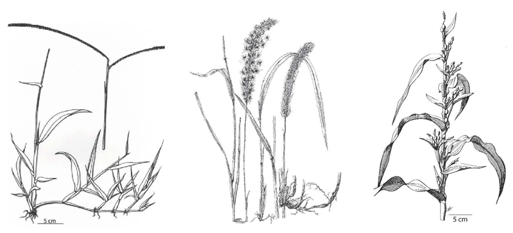

**Figure 8.5:** **Left** *Paspalum conjugatum*. Middle *Imperata cylindrica*, sword grass. **Right** Coix lacryma-jobi, Job’s tears.

In PROc, *mʷanaya, another apparently generic term for grass occurred. This quite possibly also denoted a specific but now uncertain subtaxon.

| **PROc** |  | *mʷanaya | ‘grass’ (Clark 1996: PNCV *mʷanai) |
| --- | --- | --- | --- |
| NCV | Raga | *mʷanea* | ‘grass’ |
| NCV | Avava | *mʷana* | ‘grass’ |
| NCV | Nāti | *nö-mʷönei* | ‘grass’ |
| NCV | Paamese | *munai* | ‘grass’ |
| NCV | Lewo | *ma-mʷini* | ‘grass’ |
| NCV | Nguna | *na-mʷenau* | ‘grass’ |
| SV | Lenakel | *n-mʷania* | ‘kangaroo grass, *Themeda triandra* (?)’ |
| Mic | Kiribatese | *maunei* | ‘*Cyperus laevigatus* and *Eleocharis geniculata*’ |

### 3.1. *Imperata cylindrica* (syn. *Imperata arundinacea*), sword grass, blady grass, cogon grass, TP *kunai* (Poaceae)

Alongside *Paspalum conjugatum*, grasslands in NW Melanesia are dominated by sword grass (*Imperata cylindrica*), kangaroo grass (*Themeda australis*) and *Pennisetum polystachion*. The most common of these in the Bismarcks, and the only one of the three for which a POc term is reconstructed, is sword grass (Figure 8.5, middle).

By far the most frequently reflected etymon is *Reqi(t). POc *guRun has scattered reflexes.

Blust (ACD) reconstructs PAn *Riaq ‘sword grass, *Imperata cylindrica*’ on the basis of Formosan reflexes. Whether PCEMP *Reqi is an irregular development from this, I do not know. This reconstruction is attributed to PCEMP on the basis of Far East Manggarai *riʔi* (Verheijen 1990:221), Sasak *re*, Rotinese *li* (all CMP), all ‘sword grass, *Imperata cylindrica*’. Roviana and Marovo have the form *rekiti*, reflecting earlier *rekit, but this appears to be an unsourced borrowing, as (i) the regular reflex of POc *-q- is zero and (ii) other languages which regularly retain a final POc consonant (Diodio, Wedau and Tawala) do not retain it here. The expected reflex in Roviana and Marovo is †*rei*, found in their close relative Nduke. All other languages in this cognate set with a non-zero reflex of POc *-q- reflect it regularly: no reflexes other than Roviana and Marovo require the reconstruction of *-k- in this etymon.

| **PCEMP** |  | *Reqi | ‘sword grass, *Imperata cylindrica*’ |
| --- | --- | --- | --- |
| **POc** |  | *Reqi | ‘sword grass, *Imperata cylindrica*’ |
| NNG | Tuam | *reg* | ‘*Imperata cylindrica*’ |
| NNG | Gitua | *rek* | ‘*Imperata cylindrica*’ |
| NNG | Lukep | *rei* | ‘*Imperata cylindrica*’ |
| NNG | Takia | *rei* | ‘*Imperata cylindrica*’ |
| NNG | Wogeo | *lei* | ‘*Imperata cylindrica*’ |
| NNG | Kaiep | *rei* | ‘*Imperata cylindrica*’ |
| NNG | Kairiru | *ryek* | ‘*Imperata cylindrica*’ |
| NNG | Ulau-Suain | *ri* | ‘*Imperata cylindrica*’ |
| NNG | Kela | *(ri)ri* | ‘*Imperata cylindrica*’ |
| NNG | Numbami | *lei* | ‘*Imperata cylindrica*’ |
| NNG | Patep | *heɣ* | ‘*Imperata cylindrica*’ |
| NNG | Poeng | *lai* | ‘*Imperata cylindrica*’ |
| PT | Diodio | *leyi* | ‘grass’ |
| PT | Tawala | *lei* | ‘*Imperata cylindrica*’ |
| PT | Kilivila | *lei* | ‘*Imperata cylindrica*’ |
| PT | Muyuw | *li-lei* | ‘*Imperata cylindrica*’ |
| PT | Motu | *rei* | ‘*Imperata cylindrica*’ |
| PT | Balawaia | *leɣi* | ‘grass’ |
| PT | Hula | *leɣi* | ‘*Imperata cylindrica*’ |
| MM | Bali | *re-reke* | ‘*Imperata cylindrica*’ |
| MM | Bola | *reɣi* | ‘*Imperata cylindrica*’ |
| MM | Tigak | *gi* | ‘*Imperata cylindrica*’ |
| MM | Kara (East) | *i* | ‘*Imperata cylindrica*’ |
| MM | Tabar | *ri-ri* | ‘*Imperata cylindrica*’ |
| MM | Lihir | *le* | ‘*Imperata cylindrica*’ |
| MM | Bilur | *re* | ‘*Imperata cylindrica*’ |
| MM | Tinputz | *nee* | ‘*Imperata cylindrica*’ |
| MM | Nduke | *rei* | ‘*Imperata cylindrica*’ |
| MM | Roviana | *rekiti* | ‘*Imperata cylindrica*’ (for †*rei*: borrowing?) |
| MM | Marovo | *rekiti* | ‘*Imperata cylindrica*’ (for †*rei*: borrowing?) |
| SES | Gela | *lei-lei* | ‘*Imperata cylindrica*’ |
| SES | Kwara’ae | *lai* | ‘*Imperata cylindrica*’ |
| SES | Arosi | *rei* | ‘*Imperata cylindrica*’ |
| Mic | Mokilese | *re* | ‘k.o. grass’ |

It is probable that the Central Papuan (Taboro, Hula, Motu and Doura) forms in the set below reflect borrowing from an intrusive Papuan Tip language, as they reflect *k- rather than *g- (Ross 1994a: 408).

| **PMP** |  | *guRun | ‘sword grass, *Imperata cylindrica*’[^8] |
| --- | --- | --- | --- |
| **POc** |  | *guRu(n) | ‘sword grass, *Imperata cylindrica*’ |
| NNG | Kilenge | *na-ɣu* | ‘*Imperata cylindrica*’ |
| NNG | Poeng | *gur-gur* | ‘grass’ |
| PT | Taboro | *kuru-ru* | ‘*Imperata cylindrica*’ |
| PT | Hula | *uru* | ‘species of grass’ |
| PT | Motu | *kuru-kuru* | ‘*Imperata cylindrica*’ |
| PT | Doura | *ʔuru-ʔuru* | ‘*Imperata cylindrica*’ |
| MM | Meramera | *gulu-gulu* | ‘grass’ |
| SES | Bugotu | *gu-guru* | ‘grass’ |

Blust (ACD) also reconstructs PCEMP *bitu, POc *pitu ‘*Imperata cylindrica*’ on the basis of Savu *widu*, Kambera *witu* (both CMP) and Tangga (MM) *fit*, all ‘*Imperata cylindrica*’. To these one might add Nyelayu (NCal) *uc* ‘*Imperata cylindrica*’. Blust (ACD) considers Gedaged *pit* ‘roofing material of sago leaves’ a possible member of this set, since sago leaves and sword grass are both widely used as roofing thatch. However, POc *pitu is a rather unconvincing reconstruction, the more so as other apparent Meso-Melanesian reflexes point to a hard-stemmed cane or reed as a denotatum: Patpatar, Tolai *pit*, ‘*Saccharum edule*’, Teop *vito* ‘a wild variety of S. edule’). It may be that these reflect a confusion between reflexes of POc *pitu ‘*Imperata cylindrica*’ and POc *pijo ‘cane or reed taxon, including *Saccharum spontaneum*’ (§3.4).

### 3.2. Coix lacrymajobi, Job’s tears (Poaceae)

*Coix lacryma-jobi* is a robust tropical grass, 1–1.5 m high, with shiny grains like tears (Figure 8.5, right). The grains are the hardened flower-cases of female spikelets. They turn various colours-yellow, purple, white or brown-and are used in rattles and necklaces in places as far apart as New Britain and Malaita (Kwa’ioloa & Burt 2001:204, Powell 1976). Powell reports that the leaves are eaten in New Britain.

| **POc** |  | *sila | ‘Job’s tears, *Coix lacryma-jobi*’ |
| --- | --- | --- | --- |
| Adm | Leipon | *sili-sin* | ‘*Coix lacryma-jobi*’ (Nevennann 1934) |
| SES | Kwara’ae | *sila* | ‘*Coix lacryma-jobi*’ |
| SV | Anejom̃ | *na-θec* | ‘*Coix lacryma-jobi*’ |
| Fij | Bauan | *silā* | ‘*Coix lacryma-jobi*’ |
| Fij | Wayan | *sīlā* | ‘*Coix lacryma-jobi*’ |

### 3.3. *Miscanthus floridulus* (syn. *Miscanthus japonicus*, *Saccharum floridulum*), B *waelken* (Poaceae)

A reed-like grass dominant on dry hillsides, *Miscanthus floridulus* grows to about 2m tall. In some areas it is the predominant material for constructing house walls. In Kwara’ae the solid stems are used as roof battens to which sago thatch is attached, and also as arrow-shafts (Peekel 1984: 47, Kwa’ioloa & Burt 2001: 203).

| **POc** |  | *pi(y)uŋ | ‘*Miscanthus floridulus*’ |
| --- | --- | --- | --- |
| MM | Nduke | *piu* | ‘*Miscanthus floridulus*’ (unexpected final consonant deletion) |
| MM | Roviana | *piu* | ‘*Miscanthus floridulus*’ (unexpected final consonant deletion) |
| MM | Marovo | *piu* | ‘small bamboo, used for fishing arrows’ (unexpected final consonant deletion) |
| NCV | Uripiv | *na-viʙ* | ‘*Miscanthus floridulus*’ |
| NCV | Tape | *vieb* | ‘*Miscanthus floridulus*’ |
| NCV | Avava | *viaʙ* | ‘*Miscanthus floridulus*’ |
| **PSV** |  | *na-(v)iuŋ | ‘wild cane’ (Lynch 2001c) |
| SV | Sye | *(nre)n-yuŋ* | ‘wild cane’ |
| SV | Sye | *(pol)yuŋ* | ‘wild cane’ |
| SV | Ura | *(la)n-yeŋ* | ‘wild cane’ |
| SV | Lenakel | *nu-viŋ* | ‘wild cane’ |
| SV | Kwamera | *n-iŋ* | ‘wild cane’ |
| SV | Anejom̃ | *ni-yeŋ* | ‘wild cane’ |

### 3.4. *Saccharum spontaneum*, wild sugarcane (Poaceae)

*Saccharum spontaneum* is a tall grass up to 3m in height, with jointed, fibrous stalks similar to those of sugarcane, *Saccharum officinarum* (ch.13, §2.1), to which it is quite closely related. Its English name ‘wild sugarcane’ reflects an earlier belief that it was the wild source of sugarcane.

The reconstruction below originates with French-Wright (1983), who glosses the form as ‘a kind of wild sugarcane’. An expanded cognate set was given with the reconstruction *pijo ‘Saccharum sp.’ in Ross (1996d), but some of the items listed there are now attributed to POc *bitu(ŋ) ‘bamboo sp.’ (ch.13, §3.1). Chowning (2001: 81) criticises the sugarcane/Saccharum gloss as too precise, and I have modified the gloss below to take account of the reflexes in the New Guinea region that have other denotations.

| **POc** |  | *pijo | ‘cane or reed taxon, including *Saccharum spontaneum*’ (French-Wright 1983: *piso*; Milke 1968: piso ‘k.o. reed’) |
| --- | --- | --- | --- |
| NNG | Mangap | *mbiizi* | ‘reed, pitpit type plant’ |
| NNG | Kairiru | *vis* | ‘pitpit, *Saccharum spontaneum*, a wild sugarcane type with edible fruit’ |
| PT | Motu | *hido* | ‘a wild cane growing by the riverside’ |
| MM | Bola | *viro* | ‘sugar cane, *Saccharum edule*’ |
| MM | Nakanai | *viro* | ‘a hollow-stemmed reed, Phragmites sp.’ |
| MM | Tabar | *viso* | ‘bamboo’ |
| **PEOc** |  | *piso | ‘Saccharum sp.’ |
| SES | Gela | *viho* | ‘a sp. of shore lily, Crinum’ |
| NCV | Mwotlap | *viho* | ‘*Saccharum spontaneum*’ |
| NCV | Mota | *viso* | ‘a reed, Arundo, with edible flower heads’ |
| NCV | Araki | *viso* | ‘*Saccharum edule*’ |
| NCV | Raga | *viho* | ‘*Saccharum edule*’ |
| NCV | Kiai | *viso* | ‘*Saccharum edule*’ |
| NCV | Big Nambas | *n-is(əs)* | ‘wild cane’ |
| NCV | Uripiv | *na-vis* | ‘*Saccharum edule*’ |
| NCV | Port Sandwich | *na-vis* | ‘edible reed’ |
| NCV | Tape | *nə-vəs* | ‘*Saccharum spontaneum*’ |
| NCV | Avava | *a-vis* | ‘*Saccharum spontaneum*’ |
| NCV | Nese | *na-vse* | ‘*Saccharum spontaneum*’ |
| NCV | Lonwolwol | *eh* | ‘a vegetable growing on stalks, in clumps, with soft green sheathing; its flesh, remotely like cauliflower flesh, it is roasted in fire in the sheath’ |
| NCV | Labo | *ni-vie* | ‘edible reed’ |
| NCV | Lewo | *vio* | ‘cane flower (edible)’ |
| NCV | Namakir | *vis* | ‘*Saccharum edule*’ |
| NCV | Nguna | *na-viiso* | ‘edible reed’ |
| Fij | Bauan | *viðo* | ‘a wild sugarcane, *Saccharum floridulum*’ |
| Pn | Samoan | *fiso* | ‘a large reed, *Erianthus maximus*; stems contain sugar’ (Whistler 2000: 165) |
| Pn | Emae | *fiso* | ‘edible wild cane, probably *Saccharum edule*’ |

## Notes

[^1]: Further south, in the Solomons and especially in Vanuatu, tracts of primary forest are frequently damaged or destroyed by cyclonic storms, providing an environment for secondary regrowth, but the weather closer to the equator is considerably calmer in this regard (see vol.2, ch.5).
[^2]: In Ross (1988) the items here glossed ‘caulking material’ were glossed ‘putty nut’, but this was an error, as more recently available references to the caulking material indicate that it is the sap of a *Glochidion* species, not of *Parinari*. Reflexes of *jimiR listed there included Tabar *cim*, Lamasong, Madak, Barok *sim*, all ‘canoe’. They are excluded here because of the doubtful semantic connection.
[^3]: Medial *-n-* of Patpatar *karanek* may represent an unexplained irregularity or may be a transcription error in Peekel (1984:153).
[^4]: PPn *-l- for †*-r- is attested by Tongan *-l-* for †zero.
[^5]: Chowning (pers. comm.) reports the custom in southern New Britain and up into the Gazelle Peninsula, in the D’Entrecasteaux Archipelago and in parts of the Solomons. She gives a cognate set supporting PWOc *tapal(a), denoting the blackening material or the process: Tolai *taval*, Molima *tavana*, Roviana *davala* (*d-* for †*t-*) (Chowning 1991: 48–49).
[^6]: J. Parham (1972). Bua is on Vanua Levu.
[^7]: Given Peekel’s comment that *Trichospermum pleiostigma* is restricted to the south of New Ireland, *Trichospermum peekelii* to the north, this identification may be incorrect.
[^8]: PMP *guRun is reconstructed on the basis of the Oceanic data here and of Ifugao *gulun*, Bontok, Inibaloi *golon*, Tagalog *kogon*, Bikol *gogon*, Hanunuo *kugun*, all ‘*Imperata cylindrica*’ (Madulid 2001b: 165).